Recently much of my work has been revolving around building a trading strategy that optmises on the mean reverting behaviour of the stock market.

This blog post is to give insights into some of the interesting tools i have had the pleasure of working with.

## Ornstein-Uhlenbeck process

$$dX_t = \mu \cdot (\theta - X_t)dt + \sigma dB_t$$

with constants $\mu, \sigma > 0, \theta \in \mathbb{R}$, and state space $\mathbb{R}$. Here, B is a standard Brownian motion under $\mathbb{P}$ (historical probability measure), denote by $\mathbb{F} = (F_t)_{t≥0}$ the filtration generated by X.

## Pairs Trading example

$$X_t^{\alpha,\beta} = \alpha S_t^{(1)} - \beta S_t^{(2)} \\ at \space time \space t ≥ 0.$$
The pair of assets are selected to form a mean-reverting portfolio value. In addtion, one can adjust the strategy $(\alpha , \beta)$ to enhance the value of mean-reversion.

under the model

$$ƒ^{OU}(x_i|x_{i-1};\theta,\mu,\sigma) = \frac{1}{\sqrt(2\pi\sigma¨^{2})}exp(-\frac{(x_{i}-x{i-1}e^{-\mu∆t} - \theta(1-e^{-\mu∆t}))^2}{2\sigma¨^2})$$

with the constant
$$\sigma¨^2 = \sigma^2\frac{1-e^{-2\mu∆t}}{2\mu}$$

the conditional probability density of $X_t$ at $t_i$ given $x_{i-1}$ at $t_{i-1}$ with time increment $∆t = t_i - t_{i-1}$.

Maximising the average log-likelihood over $\theta,\mu \space and \space \sigma$ for a given strategy $(\alpha, \beta)$. For any $\alpha$, we choose the strategy $(\alpha, \beta^*)$, where ß is the argmax of the log likelihood equation.

think of $\alpha = B/S_0^{(2)}$ shares is held and at the same time we short $\beta = B/S_0^{(2)}$ shares in $S_0^{(2)}$. This way the sign of the initial portfolio values depends on the sign of the difference A - B which is non- negative. Without loss of generality, we set A=1.

## Log-likelihood function:

Using the observed $(x_i^{\alpha,\beta})_{i=0,1,...,n}$, we maximise the average log-likelihood defined by.
$$l(\theta, \mu,\sigma | x_{0}^{\alpha,\beta},x_{1}^{\alpha,\beta},…,x_{n}^{\alpha,\beta}) := 1/n \sum^{n}_{i=1}lnƒ^{OU}(x_{i}^{\alpha,\beta}|x_{i-1}^{\alpha,\beta};\theta,\mu,\sigma) \\
=\frac{-1}{2ln(2\pi)} - ln(\sigma¨) - \frac{1}{2n\sigma¨^{2}} \sum^{n}_{i=1} [x_{i}^{\alpha,\beta} - x_{i-1}^{\alpha,\beta}e^{\mu∆t}-\theta(1-e^{-\mu∆t})]^2$$

### Example

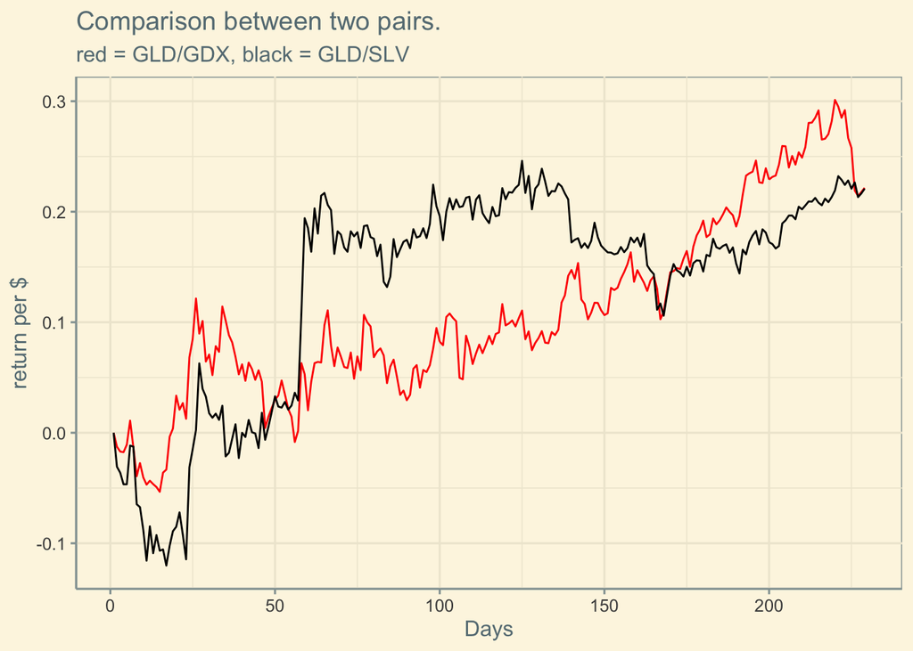

Shown above is the performance of a portfolio that has $\beta =1$ hence the equal ratio of spending is done in going long on GLD and shorting GDX (SLV).

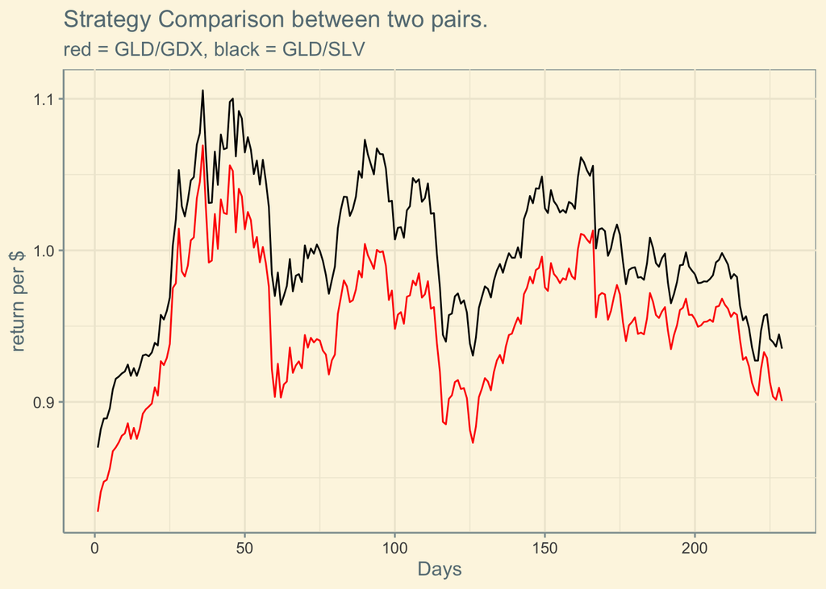

The above chart shows the comparison between the two pairs trading examples using the optimised beta levels obtained through the use of the model.

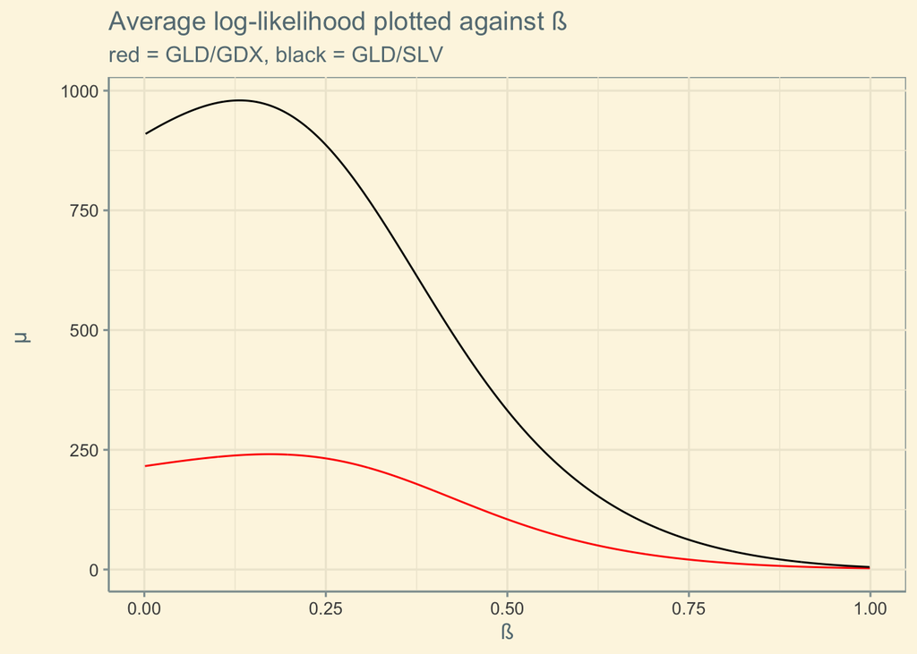

*Citations: I came across this model and working in Optimal Mean Reversion Trading with Transaction Costs and Stop-Loss Exit paper by Tim Leung and Xin Li.*